# SF Bay Microplastics Probability Distributions

Scott Coffin

1/13/2021

The objective of this project is to determine site-specific SSDs for plastic particles in the SF Bay. Particle distribution data for plastic particles is from the CEDEN databse, which was downloaded and sent to me by Dr. Diana Lin at SFEI (“2020-09-08_MooreParticleData.xlsx”)

#library

```r
library(tidyverse)
library(ssdtools)
library(fitdistrplus)
library(rbin)
library(ggpmisc)
```

# 1 Constants and Functions

```r
my.formula <- y ~ x # for linear plotting
```

# 2 SF Bay Data

## 2.1 Import data

```r
#site-specific distribution data
#SF bay data for all particles obtained via all sampling apparatus' for all matrices
distributions <- readxl::read_xlsx("data/2020-09-08_MooreParticleData.xlsx") %>%
  mutate(Size_um = 1000 * Length.mm) %>%
#annotate matrices
    mutate(matrix = case_when(grepl("sediment", MatrixName) ~ "sediment",
                            grepl("runoff", MatrixName) ~ "runoff",
                            grepl("samplewater", MatrixName) ~ "samplewater",
                            grepl("tissue", MatrixName) ~ "tissue",
                            grepl("blankwater", MatrixName) ~ "blankwater",
                            grepl("effluent", MatrixName) ~ "effluent")) %>%
  #annotate size cutoffs
  mutate(lower_size_limit_um = as.numeric(case_when(grepl(">125",MatrixName) ~ "125",
                                                 grepl(">355",MatrixName) ~ "355",
                                                 grepl(">500",MatrixName) ~ "500",
                                                 grepl(">1",MatrixName) ~ "1000"))) %>%
  #annotate size cutoffs
  mutate(upper_size_limit_um = as.numeric(case_when(grepl("125 um",MatrixName) ~ "125",
                                                 grepl("355 um",MatrixName) ~ "355",
                                                 grepl("500 um",MatrixName) ~ "500",
                                                 grepl("1000 um",MatrixName) ~ "1000"))) %>%
  mutate_if(is.character,  as.factor)

skimr::skim(distributions)
```

Data summary

| Name | distributions |
| --- | --- |
| Number of rows | 44226 |
| Number of columns | 12 |
| _______________________ |  |
| Column type frequency: |  |
| factor | 7 |
| numeric | 5 |
| ________________________ |  |
| Group variables | None |

**Variable type: factor**

| skim_variable | n_missing | complete_rate | ordered | n_unique | top_counts |
| --- | --- | --- | --- | --- | --- |
| SampleMatrix | 0 | 1 | FALSE | 5 | man: 20164, sw: 12525, sed: 6022, eff: 3510 |
| SampleID | 0 | 1 | FALSE | 306 | CB9: 4957, CB8: 2675, 19-: 2346, SB1: 1848 |
| PlasticType | 0 | 1 | FALSE | 49 | Not: 37107, Ant: 1545, Pol: 1174, Pol: 507 |
| MorphologicalCategory | 5 | 1 | FALSE | 6 | Fib: 22012, Fra: 17804, Foa: 2507, Fil: 975 |
| Color | 20 | 1 | FALSE | 18 | Bla: 11751, Cle: 8945, Whi: 5991, Blu: 5947 |
| MatrixName | 0 | 1 | FALSE | 19 | sam: 15841, run: 8360, sed: 3936, tis: 2005 |
| matrix | 0 | 1 | FALSE | 6 | sam: 20164, run: 12401, sed: 6022, eff: 3424 |

**Variable type: numeric**

| skim_variable | n_missing | complete_rate | mean | sd | p0 | p25 | p50 | p75 | p100 | hist |
| --- | --- | --- | --- | --- | --- | --- | --- | --- | --- | --- |
| Length.mm | 24069 | 0.46 | 2.05 | 21.89 | 0 | 0.49 | 0.98 | 1.99 | 3034 | ▇▁▁▁▁ |
| Width.mm | 24045 | 0.46 | 0.40 | 2.71 | 0 | 0.02 | 0.04 | 0.32 | 270 | ▇▁▁▁▁ |
| Size_um | 24069 | 0.46 | 2049.07 | 21889.31 | 0 | 487.00 | 984.28 | 1988.00 | 3034000 | ▇▁▁▁▁ |
| lower_size_limit_um | 2231 | 0.95 | 240.35 | 221.84 | 125 | 125.00 | 125.00 | 355.00 | 1000 | ▇▂▁▁▁ |
| upper_size_limit_um | 3717 | 0.92 | 440.71 | 199.26 | 355 | 355.00 | 355.00 | 355.00 | 1000 | ▇▁▁▁▁ |

```r
#This dataset contains a mixture of polymer types, including known plastics, known non-plastics, and unknowns. Summarize below
sum <- distributions %>%
  group_by(PlasticType) %>%
  summarize(count = n()) %>%
  mutate(freq = formattable::percent(count/sum(count))) %>%
  arrange(desc(freq))

sum
```

```
## # A tibble: 49 x 3
##    PlasticType                  count freq
##    <fct>                        <int> <formttbl>
##  1 Not Characterized            37107 83.90%
##  2 Anthropogenic (unknown base)  1545 3.49%
##  3 Polyethylene                  1174 2.65%
##  4 Polypropylene                  507 1.15%
##  5 Unknown                        488 1.10%
##  6 Polystyrene                    399 0.90%
##  7 Anthropogenic (cellulosic)     391 0.88%
##  8 Polyester                      364 0.82%
##  9 Unknown Potentially Rubber     298 0.67%
## 10 Acrylic                        243 0.55%
## # ... with 39 more rows
```

How many were unknown or natural?

```r
sum %>%
  mutate(general = case_when(
    #reclassify with word extraction
    grepl("Unknown", PlasticType, ignore.case = TRUE) ~ "unknown",
    grepl("anthropogenic", PlasticType, ignore.case = TRUE) ~ "unknown",
    grepl("natural", PlasticType, ignore.case = TRUE) ~ "natural",
    #further manually reclassify
    PlasticType == "Wool" ~ "natural",
    PlasticType == "Cotton" ~ "natural",
    PlasticType == "Cellulosic" ~ "natural",
    PlasticType == "Glass" ~ "anthropogenic (not plastic)",
    PlasticType == "Asphalt" ~ "anthropogenic (not plastic)",
    PlasticType == "Not Characterized" ~ "Not Characterized"
    )) %>%
  replace_na(list(general = "plastic")) %>%
  group_by(general) %>%
  summarize(freq_total = sum(freq)) %>%
  janitor::adorn_totals()
```

```
##                      general freq_total
##  anthropogenic (not plastic)      0.05%
##                      natural      1.39%
##            Not Characterized     83.90%
##                      plastic      7.96%
##                      unknown      6.69%
##                        Total    100.00%
```

```r
#list levels for plastic ID
levels(distributions$PlasticType)
```

```
##  [1] "Acrylic"
##  [2] "Acrylonitrile butadiene styrene"
##  [3] "Anthropogenic (cellulosic)"
##  [4] "Anthropogenic (protein base)"
##  [5] "Anthropogenic (synthetic)"
##  [6] "Anthropogenic (unknown base)"
##  [7] "Asphalt"
##  [8] "Cellulose acetate"
##  [9] "Cellulosic"
## [10] "Cotton"
## [11] "Ethylene/vinyl acetate copolymer"
## [12] "Fluoroelastomer"
## [13] "Glass"
## [14] "Inorganic natural material"
## [15] "Methyl vinyl ether copolymers"
```

[output cut: 34 more lines]

```r
distributions <- distributions %>%
     mutate(general = case_when(
    grepl("Unknown", PlasticType, ignore.case = TRUE) ~ "unknown",
    grepl("anthropogenic", PlasticType, ignore.case = TRUE) ~ "anthropogenic (not plastic)",
    grepl("natural", PlasticType, ignore.case = TRUE) ~ "natural",
    PlasticType == "Non-Synthetic Fiber (cotton, silk, wool)" ~ "natural",
    PlasticType == "Wool" ~ "natural",
    PlasticType == "Cotton" ~ "natural",
    PlasticType == "Cellulosic" ~ "natural",
    PlasticType == "Glass" ~ "anthropogenic (not plastic)",
    PlasticType == "Asphalt" ~ "anthropogenic (not plastic)",
    PlasticType == "Not Characterized" ~ "Not Characterized",
    PlasticType == "Stearates, Lubricants" ~ "anthropogenic (not plastic)"
    )) %>%
  replace_na(list(general = "plastic")) %>%
  #remove non-plastics
  filter(general == "plastic") %>%
    #filter(!str_detect(SampleID, "DUP")) %>%
  filter(!str_detect(SampleID, "blank")) %>% #remove blanks
  #annotate season
  mutate(season = case_when(grepl("Nov|Dec|Jan|Feb|Mar", SampleID, ignore.case = TRUE) ~ "wet",
                            grepl("Aug|Sep", SampleID, ignore.case = TRUE) ~ "dry")) %>%
   mutate(site = case_when(
    grepl("NB", SampleID,ignore.case = FALSE) ~ "North Bay",
    grepl("CB", SampleID,ignore.case = FALSE) ~ "Central Bay",
    grepl("SB10", SampleID,ignore.case = FALSE) ~ "South Bay",
    grepl("SB11", SampleID,ignore.case = FALSE) ~ "South Bay",
    grepl("SB12", SampleID,ignore.case = FALSE) ~ "South Bay",
    grepl("SB13", SampleID,ignore.case = FALSE) ~ "South Bay",
    grepl("LSB", SampleID,ignore.case = FALSE) ~ "Lower South Bay",
    grepl("NMS", SampleID,ignore.case = FALSE) ~ "National Marine Sanctuary",
    grepl("TB", SampleID,ignore.case = FALSE) ~ "Tomales Bay",
    grepl("SC", SampleID,ignore.case = FALSE) ~ "general",
    grepl("SUB", SampleID,ignore.case = FALSE) ~ "Suisin Bay",
    grepl("SOSL", SampleID,ignore.case = FALSE) ~ "general",
    grepl("Treasure", SampleID,ignore.case = FALSE) ~ "Central Bay",
    grepl("SPB", SampleID,ignore.case = FALSE) ~ "San Pablo Bay",
  ))

skimr::skim(distributions)
```

Data summary

| Name | distributions |
| --- | --- |
| Number of rows | 3517 |
| Number of columns | 15 |
| _______________________ |  |
| Column type frequency: |  |
| character | 3 |
| factor | 7 |
| numeric | 5 |
| ________________________ |  |
| Group variables | None |

**Variable type: character**

| skim_variable | n_missing | complete_rate | min | max | empty | n_unique | whitespace |
| --- | --- | --- | --- | --- | --- | --- | --- |
| general | 0 | 1.00 | 7 | 7 | 0 | 1 | 0 |
| season | 1454 | 0.59 | 3 | 3 | 0 | 2 | 0 |
| site | 944 | 0.73 | 7 | 25 | 0 | 8 | 0 |

**Variable type: factor**

| skim_variable | n_missing | complete_rate | ordered | n_unique | top_counts |
| --- | --- | --- | --- | --- | --- |
| SampleMatrix | 0 | 1 | FALSE | 5 | man: 2059, eff: 553, sed: 338, sw: 337 |
| SampleID | 0 | 1 | FALSE | 240 | CB9: 587, LSB: 119, CB8: 102, CCC: 98 |
| PlasticType | 0 | 1 | FALSE | 35 | Pol: 1174, Pol: 507, Pol: 399, Pol: 364 |
| MorphologicalCategory | 0 | 1 | FALSE | 6 | Fra: 1281, Fib: 795, Foa: 544, Sph: 430 |
| Color | 2 | 1 | FALSE | 17 | Whi: 909, Cle: 777, Blu: 442, Bla: 276 |
| MatrixName | 0 | 1 | FALSE | 18 | sam: 1270, sam: 389, eff: 273, eff: 264 |
| matrix | 0 | 1 | FALSE | 6 | sam: 2059, eff: 537, sed: 338, run: 324 |

**Variable type: numeric**

| skim_variable | n_missing | complete_rate | mean | sd | p0 | p25 | p50 | p75 | p100 | hist |
| --- | --- | --- | --- | --- | --- | --- | --- | --- | --- | --- |
| Length.mm | 452 | 0.87 | 2.81 | 7.70 | 0 | 0.49 | 0.98 | 2.46 | 147.5 | ▇▁▁▁▁ |
| Width.mm | 450 | 0.87 | 1.15 | 4.41 | 0 | 0.10 | 0.34 | 0.75 | 117.0 | ▇▁▁▁▁ |
| Size_um | 452 | 0.87 | 2813.85 | 7701.20 | 0 | 494.00 | 980.00 | 2458.00 | 147500.0 | ▇▁▁▁▁ |
| lower_size_limit_um | 269 | 0.92 | 324.06 | 300.39 | 125 | 125.00 | 125.00 | 355.00 | 1000.0 | ▇▂▂▁▂ |
| upper_size_limit_um | 667 | 0.81 | 455.29 | 218.47 | 355 | 355.00 | 355.00 | 355.00 | 1000.0 | ▇▁▁▁▂ |

### 2.1.1 Data export

```r
write.csv(distributions,
          "output/data/cleanParticleData.csv")
```

## 2.2 Modelling

### 2.2.1 Visualization

Visualize size distribution across all matrices

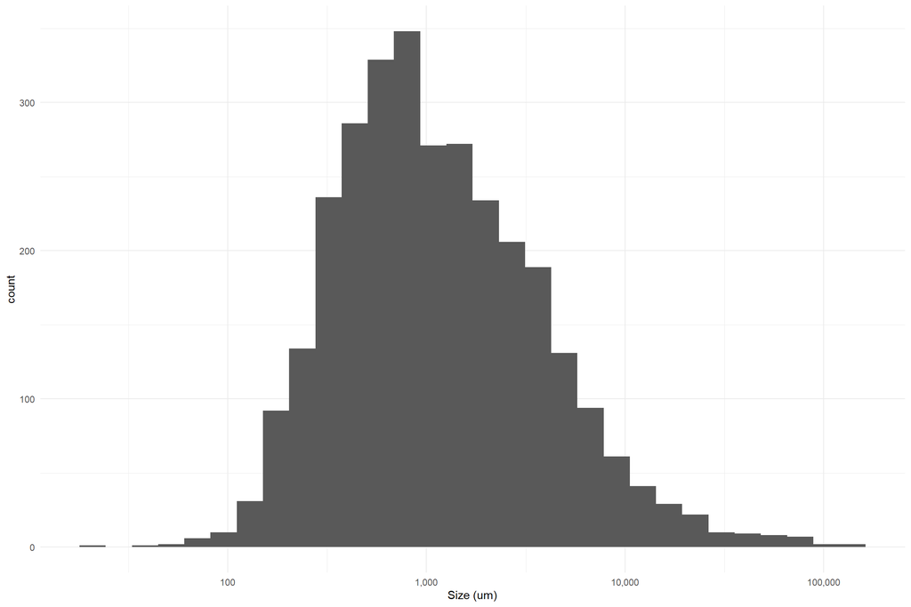

```r
distributions %>%
  ggplot(aes(x = Size_um)) +
  geom_histogram() +
  scale_x_continuous(name = "Size (um)",breaks = scales::trans_breaks("log10", function(x) 10^x),labels = comma_signif, trans = "log10")+
  theme_minimal()
```

We can see here that they do not exactly follow an alpha distribution, but this is likely due to detection limits.

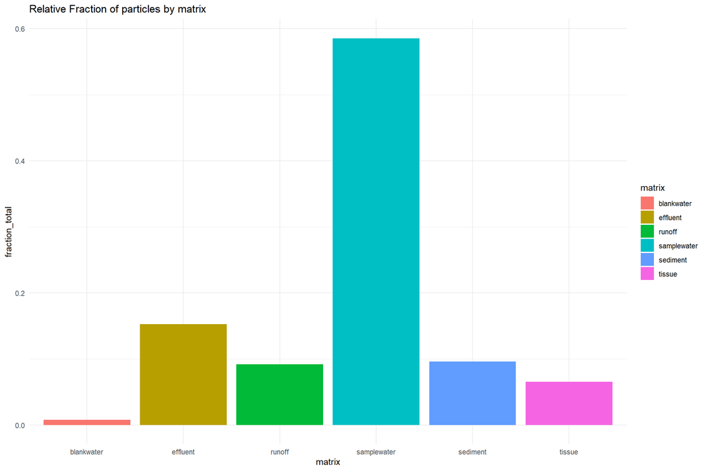

```r
distributions %>%
  group_by(matrix) %>%
  summarize(count = n()) %>%
  mutate(fraction_total = count /  sum(count)) %>%
  ggplot(aes(x = matrix, y = fraction_total, fill = matrix)) +
  geom_col() +
  labs(title = "Relative Fraction of particles by matrix") +
  theme_minimal()
```

Matrix Names: “effluent” = wastewater treatment plant discharge “runoff” = stormwater runoff “samplewater” = surface water obtained using Manta Trawl or 1-L grab samples “tissue” = fish tissue

The maximum size for which the dataset was valid is determined using a theoretical particle detection limit (PDL).

1. Data was plotted using only the values between the minimum and the first non-detect. A log-log plot for size vs abundance (#) is made.
2. A linear trendline was fitted, and the parameters for the function y = a*x + b were obtained
3. Assuming y = 0 (equals 1 particle since 10^0 = 1), a value for x (the PDL) was calculated
4. Data were plotted using only the values between the minimum and the calculated PDL
5. If more data were included than in step 1, the procedure was repeated.
6. Once the PDL does not change anymore, only data between the minimum and PDL were included for the final trendline fitting.

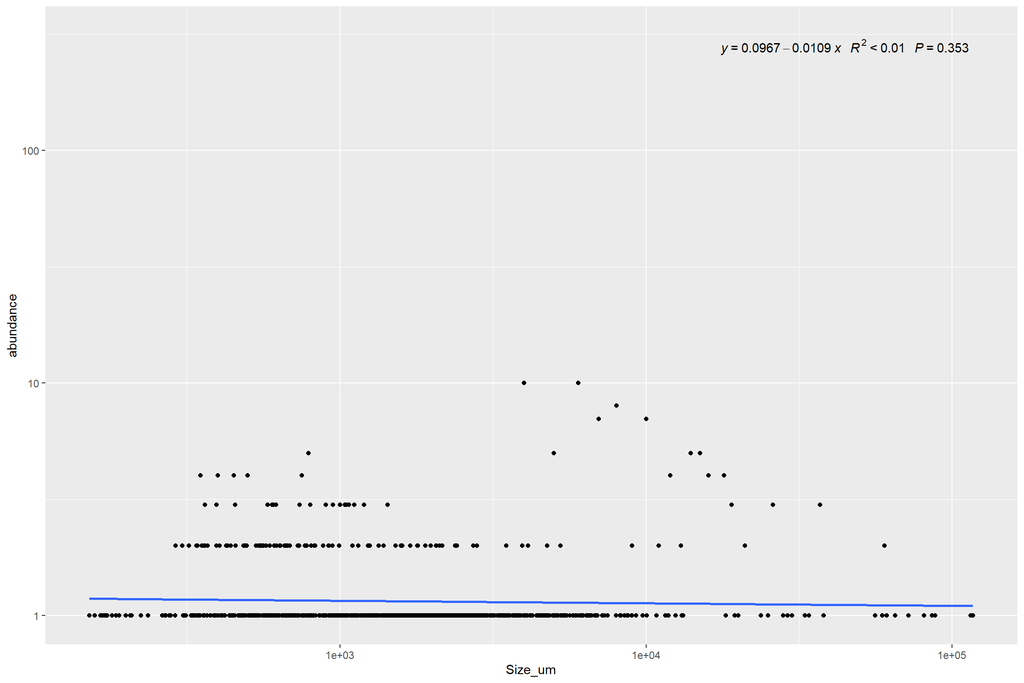

```r
sample_water <- distributions %>%
  filter(matrix == "samplewater", #surface water
         lower_size_limit_um == 125) %>%
  group_by(Size_um, lower_size_limit_um, upper_size_limit_um, SampleMatrix) %>%
  summarize(abundance = n())

sample_water %>%
  ggplot(aes(x = Size_um, y = abundance)) +
  geom_point() +
  geom_smooth(method = "lm", se=FALSE, formula = my.formula) +
   stat_poly_eq(formula = my.formula,
                aes(label = paste(..eq.label.., ..rr.label.., ..p.value.label.., sep = "~~~")),
                label.x  = "right",
                label.y = "top",
                parse = TRUE) +
  scale_x_log10() +
  scale_y_log10()
```

Here we can see that the particles do not cleanly fit an expected log-log trendline which is likely due to the way in which particle lengths are annotated. We could try rounding the particle lengths.

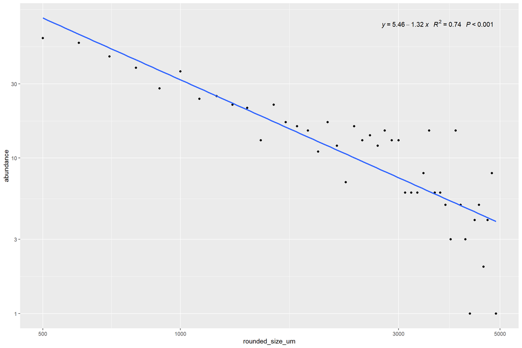

```r
distributions %>%
  filter(matrix == "samplewater",
         lower_size_limit_um == 125) %>%
  mutate(rounded_size_um = round(Size_um, -2)) %>% #round to the 100th place
  filter(rounded_size_um >= 125) %>% #if lower size limit is 125 um, ensure no particles below are considered
  filter(rounded_size_um > 400 & rounded_size_um <5000) %>%  #400 um seems to be where size counting tails off, and 5,000 um is arbitrary upper size limit for microplastics
  group_by(rounded_size_um , lower_size_limit_um, upper_size_limit_um, SampleMatrix) %>%
  summarize(abundance = n()) %>%
  ggplot(aes(x = rounded_size_um, y = abundance)) +
  geom_point() +
  geom_smooth(method = "lm", se=FALSE, formula = my.formula) +
   stat_poly_eq(formula = my.formula,
                aes(label = paste(..eq.label.., ..rr.label.., ..p.value.label.., sep = "~~~")),
                label.x  = "right",
                label.y = "top",
                parse = TRUE) +
  scale_x_log10() +
  scale_y_log10()
```

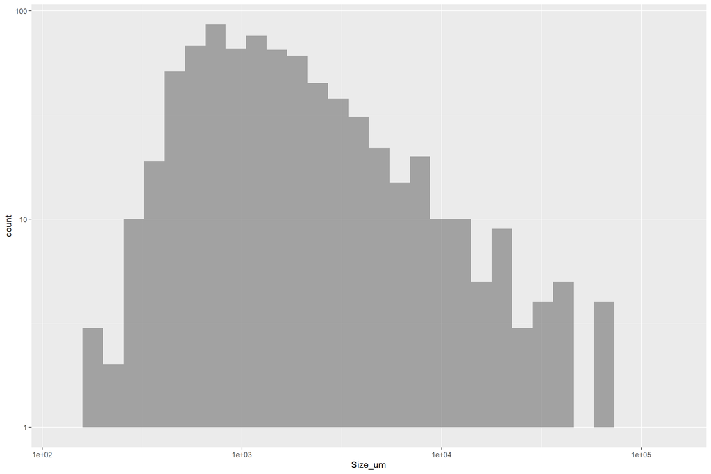

```r
distributions %>%
  filter(matrix == "samplewater") %>%
  filter(MorphologicalCategory == "Fragment") %>%
  ggplot(aes(x = Size_um)) +
  geom_histogram(alpha = 0.5) +
 # geom_smooth(method = "lm") +
  scale_x_log10() +
  scale_y_log10()
```

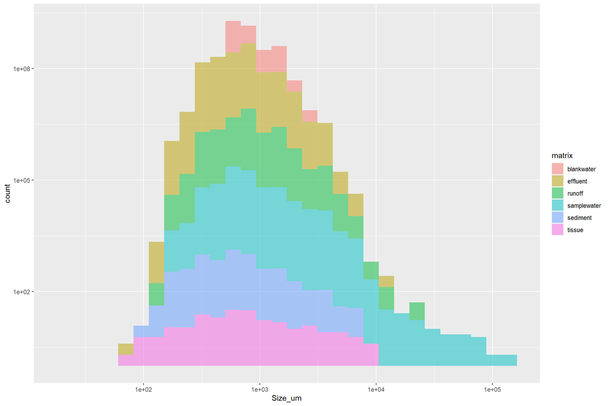

```r
distributions %>%
  #filter(matrix == "samplewater") %>%
  #filter(MorphologicalCategory == "Fragment") %>%
  ggplot(aes(x = Size_um, fill = matrix)) +
  geom_histogram(alpha = 0.5) +
 # geom_smooth(method = "lm") +
  scale_x_log10() +
  scale_y_log10()
```

We need a better way of binning data.

Winsorized binning is similar to equal length binning except that both tails are cut off to obtain a smooth binning result. This technique is often used to remove outliers during the data pre-processing stage. For Winsorized binning, the Winsorized statistics are computed first. After the minimum and maximum have been found, the split points are calculated the same way as in equal length binning.

#### 2.2.2.1 SampleWater

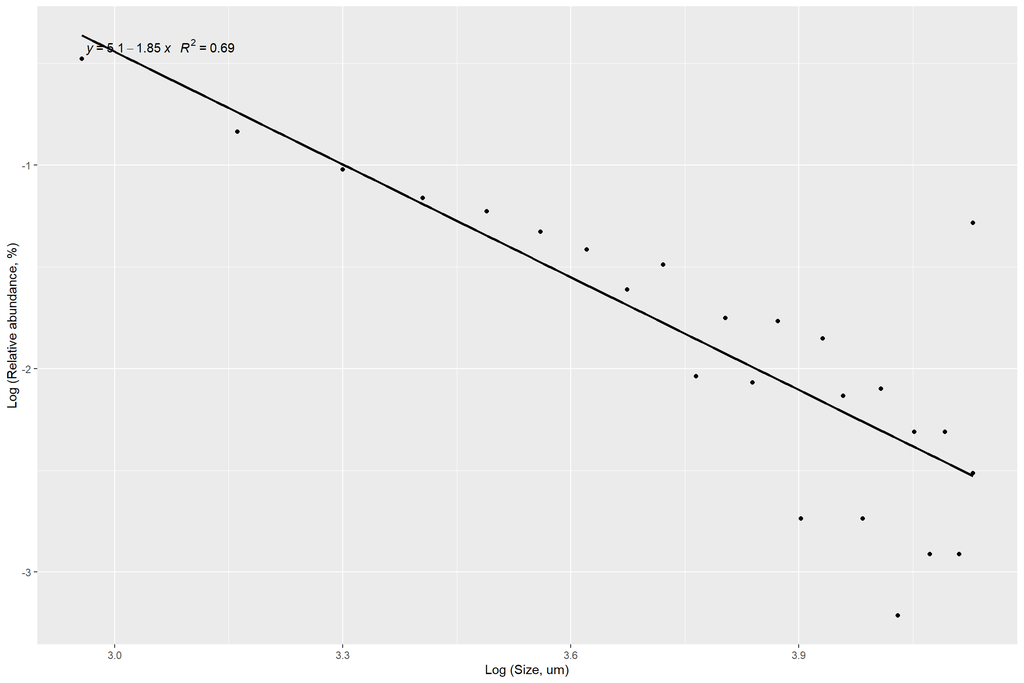

```r
#determine lower and upper end based on maximum R^2 (iteration required)
sample_water_cut <- distributions %>%
  #filter(lower_size_limit_um == 125) %>%
 # filter(MorphologicalCategory == "Fragment") %>%
  filter(matrix == "samplewater") %>%
  #filter(Size_um >1 & Size_um  <1000) %>%
  drop_na(Size_um)

#cut into bins
#sample_waterwinsors <- rbin_winsorize(sample_water_cut, polymer, Size_um, 20)
sample_waterwinsors <- rbin_winsorize(sample_water_cut, predictor = Size_um, Size_um, bins = 25, winsor_rate = 0.05, remove_na = TRUE)
#save as dataframe
sample_waterbinned <- as.data.frame(sample_waterwinsors$bins) %>%
  dplyr::select(c(cut_point, bin_count, bin_prop))

#strip of characters
sample_waterbinned$cut <- gsub("[^0-9.-]","",sample_waterbinned$cut_point)
 #convert to numeric
sample_waterbinned2 <- sample_waterbinned %>%
  mutate(cut.numeric = as.numeric(cut)) %>%
  mutate(logAbundance = log10(bin_prop),
         logSize = log10(cut.numeric))


p <- sample_waterbinned2 %>%
  #filter(logAbundance < -1.0) %>%
  ggplot(aes(x = logSize, y = logAbundance)) +
   geom_smooth(method = "lm", se=FALSE, color="black", formula = my.formula) +
   stat_poly_eq(formula = my.formula,
                aes(label = paste(..eq.label.., ..rr.label.., sep = "~~~")),
                parse = TRUE) +
   geom_point() +
  xlab("Log (Size, um)") +
  ylab("Log (Relative abundance, %)")
p
```

##### 2.2.2.1.1 Remove outliers

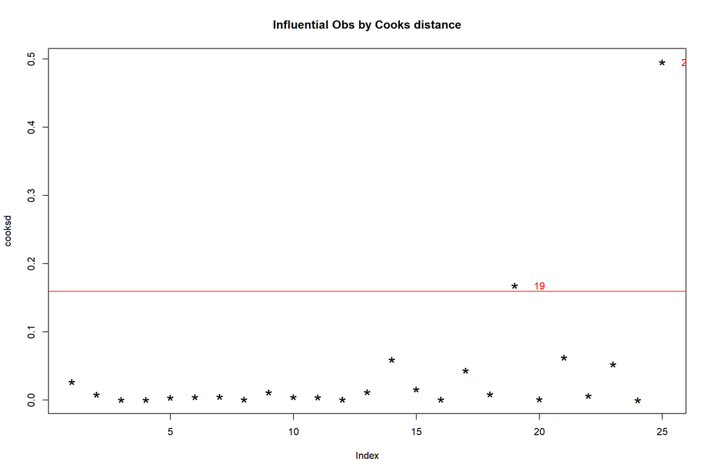

```r
sample_waterlin <- lm(logAbundance ~ logSize, data = sample_waterbinned2)
cooksd <- cooks.distance(sample_waterlin)
plot(cooksd, pch="*", cex=2, main="Influential Obs by Cooks distance")  # plot cook's distance
abline(h = 4*mean(cooksd, na.rm=T), col="red")  # add cutoff line
text(x=1:length(cooksd)+1, y=cooksd, labels=ifelse(cooksd>4*mean(cooksd, na.rm=T),names(cooksd),""), col="red")  # add labels
```

Extract outliers

```r
influential <- as.numeric(names(cooksd)[(cooksd > 4*mean(cooksd, na.rm=T))])  # influential row numbers
head(sample_waterbinned2[influential, ])  # influential observations.
```

```
##       cut_point bin_count     bin_prop       cut cut.numeric logAbundance
## 19  < 10726.256         1 0.0006116208 10726.256    10726.26    -3.213518
## 25 >= 13454.376        85 0.0519877676 13454.376    13454.38    -1.284099
##     logSize
## 19 4.030448
## 25 4.128864
```

```r
trimmedsample_water <- sample_waterbinned2[-influential,] %>%
  mutate(polymer = "sample_water")

sample_waterlin <- lm(logAbundance ~ logSize, data = trimmedsample_water)
sample_waterlin.summ <- summary(sample_waterlin)
sample_waterlin.summ
```

```
##
## Call:
## lm(formula = logAbundance ~ logSize, data = trimmedsample_water)
##
## Residuals:
##      Min       1Q   Median       3Q      Max
## -0.59568 -0.15181  0.08422  0.18690  0.34471
##
## Coefficients:
##             Estimate Std. Error t value Pr(>|t|)
## (Intercept)   5.4562     0.6730   8.108 6.64e-08 ***
## logSize      -1.9464     0.1785 -10.904 4.17e-10 ***
## ---
## Signif. codes:  0 '***' 0.001 '**' 0.01 '*' 0.05 '.' 0.1 ' ' 1
##
## Residual standard error: 0.2681 on 21 degrees of freedom
## Multiple R-squared:  0.8499, Adjusted R-squared:  0.8427
## F-statistic: 118.9 on 1 and 21 DF,  p-value: 4.169e-10
```

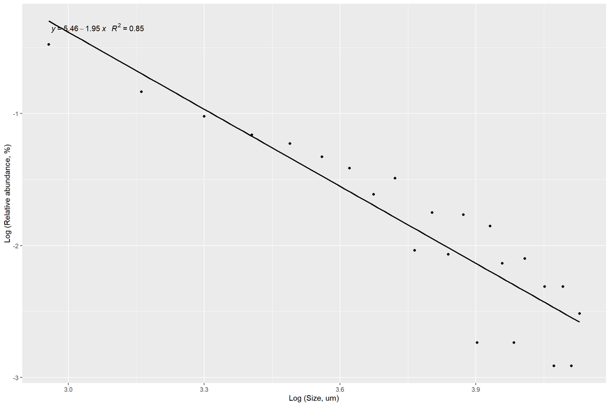

```r
ggplot(data = trimmedsample_water, aes(x = logSize, y = logAbundance)) +
   geom_smooth(method = "lm", se=FALSE, color="black", formula = my.formula) +
   stat_poly_eq(formula = my.formula,
                aes(label = paste(..eq.label.., ..rr.label.., sep = "~~~")),
                parse = TRUE) +
   geom_point() +
  xlab("Log (Size, um)") +
  ylab("Log (Relative abundance, %)")
```

##### Manta only

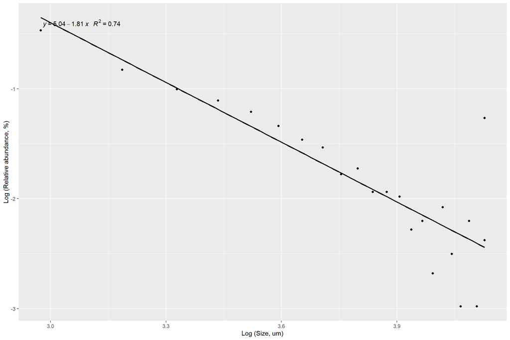

```r
#determine lower and upper end based on maximum R^2 (iteration required)
sample_water_cut <- distributions %>%
  filter(lower_size_limit_um == 125) %>%
 # filter(MorphologicalCategory == "Fragment") %>%
  filter(matrix == "samplewater") %>%
  #filter(Size_um >1 & Size_um  <1000) %>%
  drop_na(Size_um)

#cut into bins
#sample_waterwinsors <- rbin_winsorize(sample_water_cut, polymer, Size_um, 20)
sample_waterwinsors <- rbin_winsorize(sample_water_cut, predictor = Size_um, Size_um, bins = 23, winsor_rate = 0.05, remove_na = TRUE)
#save as dataframe
sample_waterbinned <- as.data.frame(sample_waterwinsors$bins) %>%
  dplyr::select(c(cut_point, bin_count, bin_prop))

#strip of characters
sample_waterbinned$cut <- gsub("[^0-9.-]","",sample_waterbinned$cut_point)
 #convert to numeric
sample_waterbinned2 <- sample_waterbinned %>%
  mutate(cut.numeric = as.numeric(cut)) %>%
  mutate(logAbundance = log10(bin_prop),
         logSize = log10(cut.numeric))

## model
library(ggpmisc)
my.formula <- y ~ x
p <- sample_waterbinned2 %>%
  #filter(logAbundance < -1.0) %>%
  ggplot(aes(x = logSize, y = logAbundance)) +
   geom_smooth(method = "lm", se=FALSE, color="black", formula = my.formula) +
   stat_poly_eq(formula = my.formula,
                aes(label = paste(..eq.label.., ..rr.label.., sep = "~~~")),
                parse = TRUE) +
   geom_point() +
  xlab("Log (Size, um)") +
  ylab("Log (Relative abundance, %)")
p
```

###### 2.2.2.1.1.1 Remove outliers

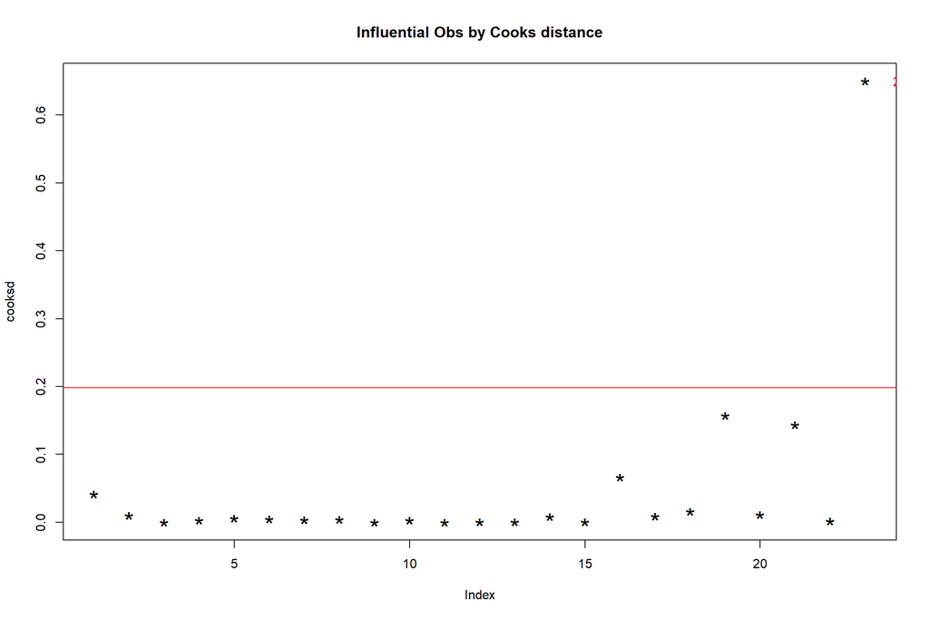

```r
sample_waterlin <- lm(logAbundance ~ logSize, data = sample_waterbinned2)
cooksd <- cooks.distance(sample_waterlin)
plot(cooksd, pch="*", cex=2, main="Influential Obs by Cooks distance")  # plot cook's distance
abline(h = 4*mean(cooksd, na.rm=T), col="red")  # add cutoff line
text(x=1:length(cooksd)+1, y=cooksd, labels=ifelse(cooksd>4*mean(cooksd, na.rm=T),names(cooksd),""), col="red")  # add labels
```

Extract outliers

```r
influential <- as.numeric(names(cooksd)[(cooksd > 4*mean(cooksd, na.rm=T))])  # influential row numbers
head(sample_waterbinned2[influential, ])  # influential observations.
```

```
##              cut_point bin_count   bin_prop              cut cut.numeric
## 23 >= 13406.5217391304        52 0.05433647 13406.5217391304    13406.52
##    logAbundance  logSize
## 23    -1.264909 4.127316
```

```r
trimmedsample_water <- sample_waterbinned2[-influential,] %>%
  mutate(polymer = "sample_water")

sample_waterlin <- lm(logAbundance ~ logSize, data = trimmedsample_water)
sample_waterlin.summ <- summary(sample_waterlin)
sample_waterlin.summ
```

```
##
## Call:
## lm(formula = logAbundance ~ logSize, data = trimmedsample_water)
##
## Residuals:
##      Min       1Q   Median       3Q      Max
## -0.53845 -0.10465  0.05573  0.15189  0.28325
##
## Coefficients:
##             Estimate Std. Error t value Pr(>|t|)
## (Intercept)   5.7439     0.6112   9.398 8.89e-09 ***
## logSize      -2.0136     0.1616 -12.460 6.98e-11 ***
## ---
## Signif. codes:  0 '***' 0.001 '**' 0.01 '*' 0.05 '.' 0.1 ' ' 1
##
## Residual standard error: 0.2346 on 20 degrees of freedom
## Multiple R-squared:  0.8859, Adjusted R-squared:  0.8802
## F-statistic: 155.2 on 1 and 20 DF,  p-value: 6.978e-11
```

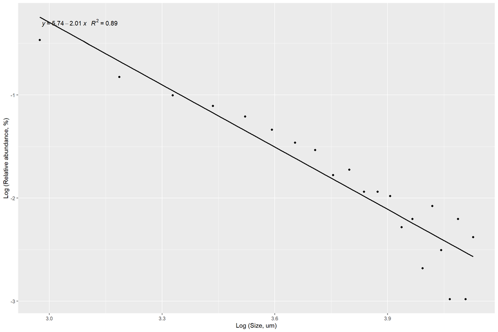

```r
ggplot(data = trimmedsample_water, aes(x = logSize, y = logAbundance)) +
   geom_smooth(method = "lm", se=FALSE, color="black", formula = my.formula) +
   stat_poly_eq(formula = my.formula,
                aes(label = paste(..eq.label.., ..rr.label.., sep = "~~~")),
                parse = TRUE) +
   geom_point() +
  xlab("Log (Size, um)") +
  ylab("Log (Relative abundance, %)")
```

### 2.2.3 Effluent

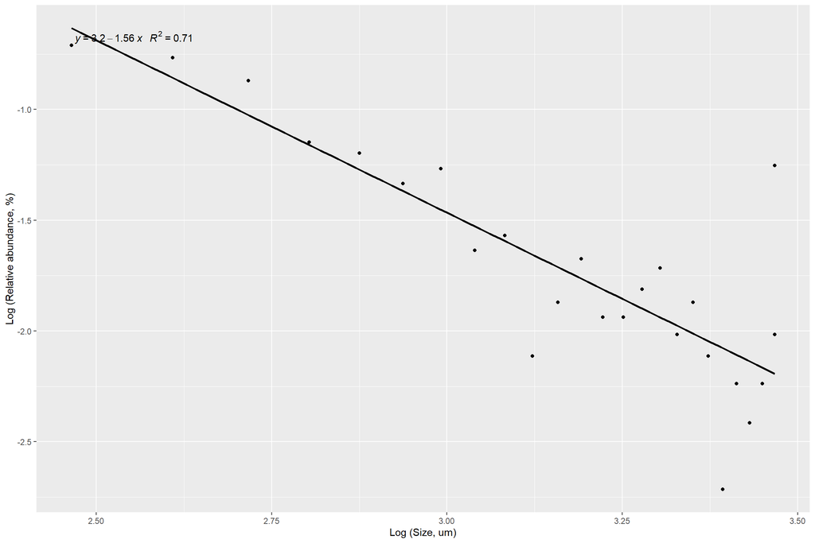

```r
#determine lower and upper end based on maximum R^2 (iteration required)
effluent_cut <- distributions %>%
  #filter(lower_size_limit_um == 125) %>%
 # filter(MorphologicalCategory == "Fragment") %>%
  filter(matrix == "effluent") %>%
  #filter(Size_um >1 & Size_um  <1000) %>%
  drop_na(Size_um)

#cut into bins
#effluentwinsors <- rbin_winsorize(effluent_cut, polymer, Size_um, 20)
effluentwinsors <- rbin_winsorize(effluent_cut, predictor = Size_um, Size_um, bins = 25, winsor_rate = 0.05)
#save as dataframe
effluentbinned <- as.data.frame(effluentwinsors$bins) %>%
  dplyr::select(c(cut_point, bin_count, bin_prop))

#strip of characters
effluentbinned$cut <- gsub("[^0-9.-]","",effluentbinned$cut_point)
 #convert to numeric
effluentbinned2 <- effluentbinned %>%
  mutate(cut.numeric = as.numeric(cut)) %>%
  mutate(logAbundance = log10(bin_prop),
         logSize = log10(cut.numeric))

## model
library(ggpmisc)
my.formula <- y ~ x
p <- effluentbinned2 %>%
  #filter(logAbundance < -1.0) %>%
  ggplot(aes(x = logSize, y = logAbundance)) +
   geom_smooth(method = "lm", se=FALSE, color="black", formula = my.formula) +
   stat_poly_eq(formula = my.formula,
                aes(label = paste(..eq.label.., ..rr.label.., sep = "~~~")),
                parse = TRUE) +
   geom_point() +
  xlab("Log (Size, um)") +
  ylab("Log (Relative abundance, %)")
p
```

##### 2.2.3.0.1 Remove outliers

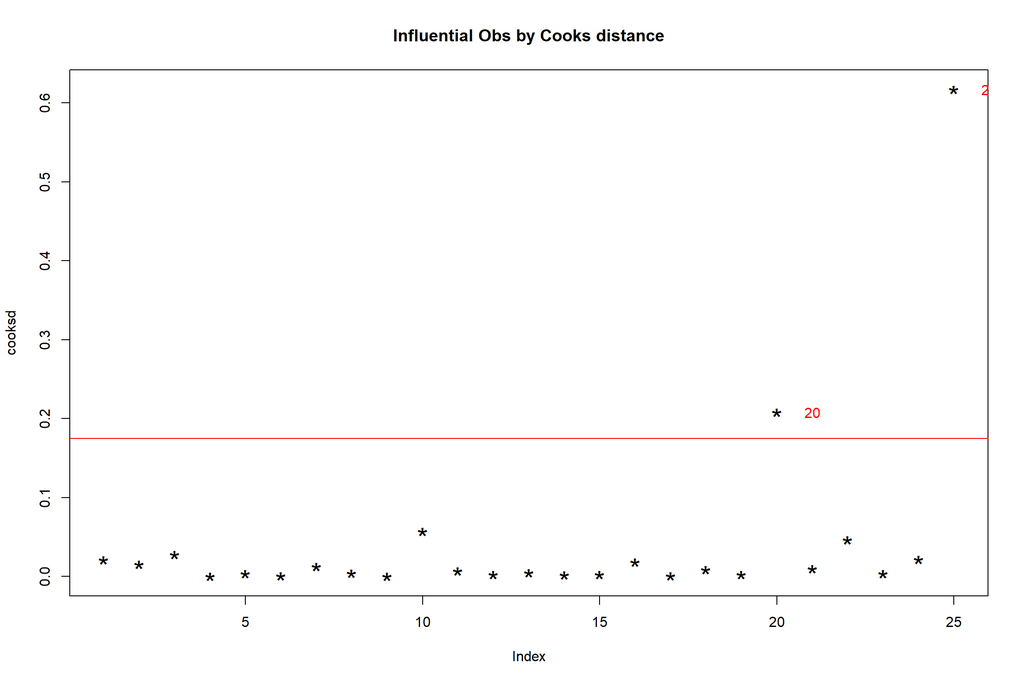

```r
effluentlin <- lm(logAbundance ~ logSize, data = effluentbinned2)
cooksd <- cooks.distance(effluentlin)
plot(cooksd, pch="*", cex=2, main="Influential Obs by Cooks distance")  # plot cook's distance
abline(h = 4*mean(cooksd, na.rm=T), col="red")  # add cutoff line
text(x=1:length(cooksd)+1, y=cooksd, labels=ifelse(cooksd>4*mean(cooksd, na.rm=T),names(cooksd),""), col="red")  # add labels
```

Extract outliers

```r
influential <- as.numeric(names(cooksd)[(cooksd > 4*mean(cooksd, na.rm=T))])  # influential row numbers
head(effluentbinned2[influential, ])  # influential observations.
```

```
##    cut_point bin_count    bin_prop    cut cut.numeric logAbundance  logSize
## 20  < 2472.7         1 0.001926782 2472.7      2472.7    -2.715167 3.393171
## 25 >= 2931.9        29 0.055876686 2931.9      2931.9    -1.252769 3.467149
```

```r
trimmedeffluent <- effluentbinned2[-influential,] %>%
  mutate(polymer = "effluent")

effluentlin <- lm(logAbundance ~ logSize, data = trimmedeffluent)
effluentlin.summ <- summary(effluentlin)
effluentlin.summ
```

```
##
## Call:
## lm(formula = logAbundance ~ logSize, data = trimmedeffluent)
##
## Residuals:
##      Min       1Q   Median       3Q      Max
## -0.44458 -0.09761 -0.00188  0.11098  0.25198
##
## Coefficients:
##             Estimate Std. Error t value Pr(>|t|)
## (Intercept)   3.4589     0.3862   8.955 1.29e-08 ***
## logSize      -1.6423     0.1231 -13.336 1.01e-11 ***
## ---
## Signif. codes:  0 '***' 0.001 '**' 0.01 '*' 0.05 '.' 0.1 ' ' 1
##
## Residual standard error: 0.1623 on 21 degrees of freedom
## Multiple R-squared:  0.8944, Adjusted R-squared:  0.8894
## F-statistic: 177.9 on 1 and 21 DF,  p-value: 1.015e-11
```

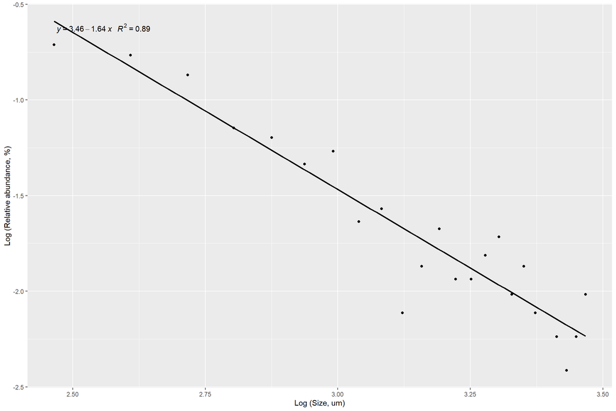

```r
ggplot(data = trimmedeffluent, aes(x = logSize, y = logAbundance)) +
   geom_smooth(method = "lm", se=FALSE, color="black", formula = my.formula) +
   stat_poly_eq(formula = my.formula,
                aes(label = paste(..eq.label.., ..rr.label.., sep = "~~~")),
                parse = TRUE) +
   geom_point() +
  xlab("Log (Size, um)") +
  ylab("Log (Relative abundance, %)")
```

### runoff

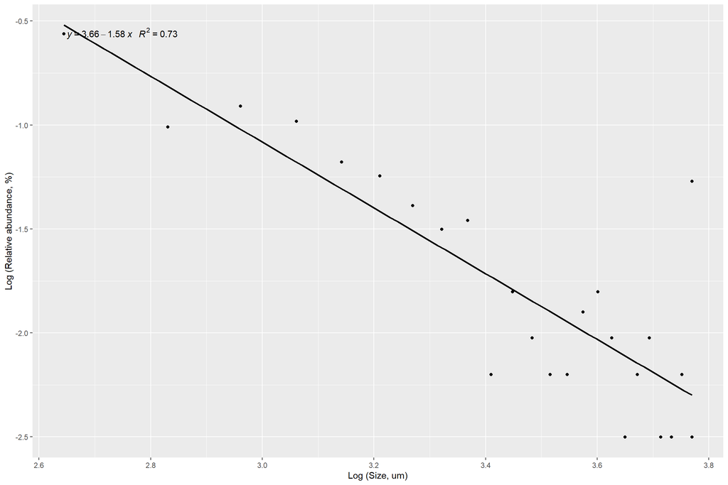

```r
#determine lower and upper end based on maximum R^2 (iteration required)
runoff_cut <- distributions %>%
  #filter(lower_size_limit_um == 125) %>%
 # filter(MorphologicalCategory == "Fragment") %>%
  filter(matrix == "runoff") %>%
  #filter(Size_um >1 & Size_um  <1000) %>%
  drop_na(Size_um)

#cut into bins
#runoffwinsors <- rbin_winsorize(runoff_cut, polymer, Size_um, 20)
runoffwinsors <- rbin_winsorize(runoff_cut, predictor = Size_um, Size_um, bins = 25, winsor_rate = 0.05)
#save as dataframe
runoffbinned <- as.data.frame(runoffwinsors$bins) %>%
  dplyr::select(c(cut_point, bin_count, bin_prop))

#strip of characters
runoffbinned$cut <- gsub("[^0-9.-]","",runoffbinned$cut_point)
 #convert to numeric
runoffbinned2 <- runoffbinned %>%
  mutate(cut.numeric = as.numeric(cut)) %>%
  mutate(logAbundance = log10(bin_prop),
         logSize = log10(cut.numeric))

## model
library(ggpmisc)
my.formula <- y ~ x
p <- runoffbinned2 %>%
  #filter(logAbundance < -1.0) %>%
  ggplot(aes(x = logSize, y = logAbundance)) +
   geom_smooth(method = "lm", se=FALSE, color="black", formula = my.formula) +
   stat_poly_eq(formula = my.formula,
                aes(label = paste(..eq.label.., ..rr.label.., sep = "~~~")),
                parse = TRUE) +
   geom_point() +
  xlab("Log (Size, um)") +
  ylab("Log (Relative abundance, %)")
p
```

##### 2.2.3.0.2 Remove outliers

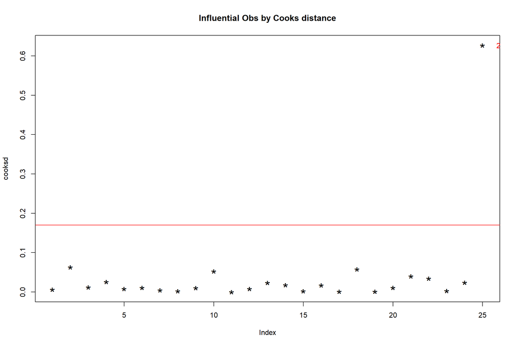

```r
runofflin <- lm(logAbundance ~ logSize, data = runoffbinned2)
cooksd <- cooks.distance(runofflin)
plot(cooksd, pch="*", cex=2, main="Influential Obs by Cooks distance")  # plot cook's distance
abline(h = 4*mean(cooksd, na.rm=T), col="red")  # add cutoff line
text(x=1:length(cooksd)+1, y=cooksd, labels=ifelse(cooksd>4*mean(cooksd, na.rm=T),names(cooksd),""), col="red")  # add labels
```

Extract outliers

```r
influential <- as.numeric(names(cooksd)[(cooksd > 4*mean(cooksd, na.rm=T))])  # influential row numbers
head(runoffbinned2[influential, ])  # influential observations.
```

```
##      cut_point bin_count   bin_prop      cut cut.numeric logAbundance logSize
## 25 >= 5882.608        17 0.05362776 5882.608    5882.608     -1.27061 3.76957
```

```r
trimmedrunoff <- runoffbinned2[-influential,] %>%
  mutate(polymer = "runoff")

runofflin <- lm(logAbundance ~ logSize, data = trimmedrunoff)
runofflin.summ <- summary(runofflin)
runofflin.summ
```

```
##
## Call:
## lm(formula = logAbundance ~ logSize, data = trimmedrunoff)
##
## Residuals:
##      Min       1Q   Median       3Q      Max
## -0.42756 -0.17013  0.05744  0.16315  0.30423
##
## Coefficients:
##             Estimate Std. Error t value Pr(>|t|)
## (Intercept)   4.1886     0.4812   8.704 1.42e-08 ***
## logSize      -1.7481     0.1403 -12.459 1.93e-11 ***
## ---
## Signif. codes:  0 '***' 0.001 '**' 0.01 '*' 0.05 '.' 0.1 ' ' 1
##
## Residual standard error: 0.2072 on 22 degrees of freedom
## Multiple R-squared:  0.8759, Adjusted R-squared:  0.8702
## F-statistic: 155.2 on 1 and 22 DF,  p-value: 1.927e-11
```

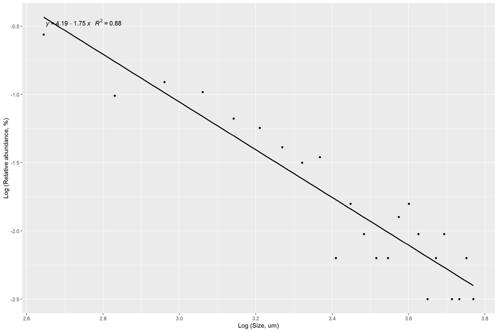

```r
ggplot(data = trimmedrunoff, aes(x = logSize, y = logAbundance)) +
   geom_smooth(method = "lm", se=FALSE, color="black", formula = my.formula) +
   stat_poly_eq(formula = my.formula,
                aes(label = paste(..eq.label.., ..rr.label.., sep = "~~~")),
                parse = TRUE) +
   geom_point() +
  xlab("Log (Size, um)") +
  ylab("Log (Relative abundance, %)")
```

### 2.2.4 Sediment

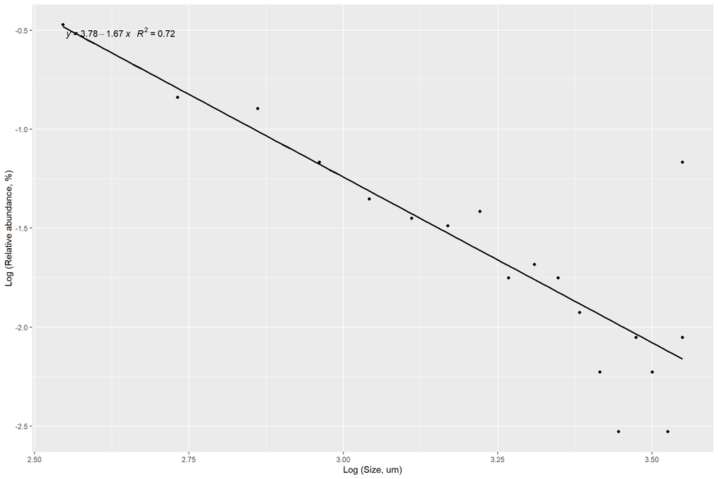

```r
#determine lower and upper end based on maximum R^2 (iteration required)
sediment_cut <- distributions %>%
  #filter(lower_size_limit_um == 125) %>%
 # filter(MorphologicalCategory == "Fragment") %>%
  filter(matrix == "sediment") %>%
  #filter(Size_um >1 & Size_um  <1000) %>%
  drop_na(Size_um)

#cut into bins
#sedimentwinsors <- rbin_winsorize(sediment_cut, polymer, Size_um, 20)
sedimentwinsors <- rbin_winsorize(sediment_cut, predictor = Size_um, Size_um, bins = 19, winsor_rate = 0.05)
#save as dataframe
sedimentbinned <- as.data.frame(sedimentwinsors$bins) %>%
  dplyr::select(c(cut_point, bin_count, bin_prop))

#strip of characters
sedimentbinned$cut <- gsub("[^0-9.-]","",sedimentbinned$cut_point)
 #convert to numeric
sedimentbinned2 <- sedimentbinned %>%
  mutate(cut.numeric = as.numeric(cut)) %>%
  mutate(logAbundance = log10(bin_prop),
         logSize = log10(cut.numeric))

## model
library(ggpmisc)
my.formula <- y ~ x
p <- sedimentbinned2 %>%
  #filter(logAbundance < -1.0) %>%
  ggplot(aes(x = logSize, y = logAbundance)) +
   geom_smooth(method = "lm", se=FALSE, color="black", formula = my.formula) +
   stat_poly_eq(formula = my.formula,
                aes(label = paste(..eq.label.., ..rr.label.., sep = "~~~")),
                parse = TRUE) +
   geom_point() +
  xlab("Log (Size, um)") +
  ylab("Log (Relative abundance, %)")
p
```

##### 2.2.4.0.1 Remove outliers

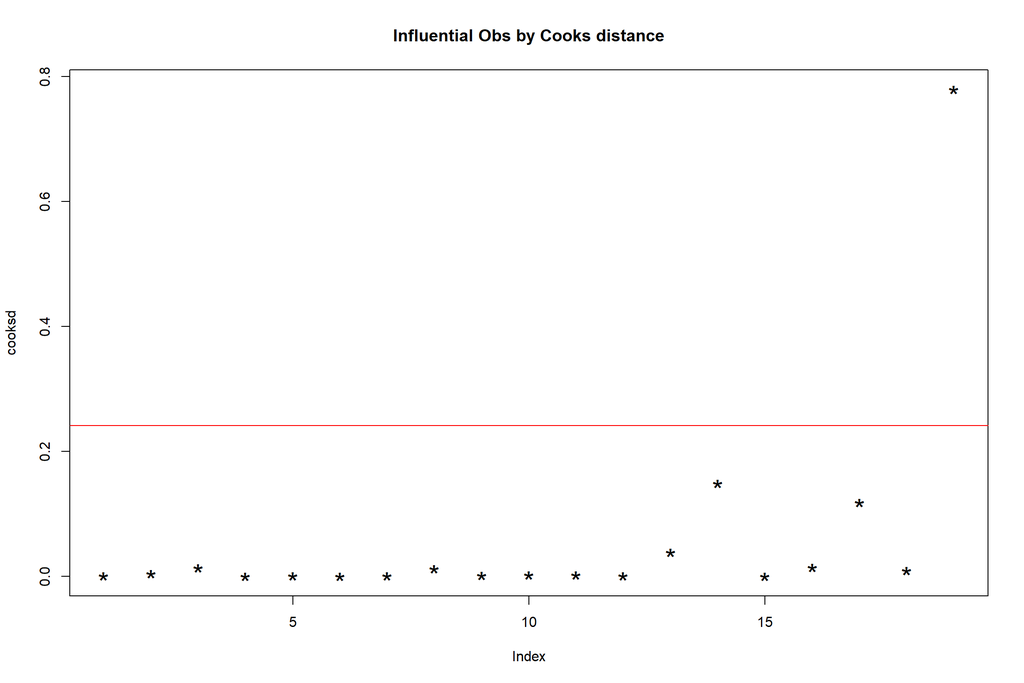

```r
sedimentlin <- lm(logAbundance ~ logSize, data = sedimentbinned2)
cooksd <- cooks.distance(sedimentlin)
plot(cooksd, pch="*", cex=2, main="Influential Obs by Cooks distance")  # plot cook's distance
abline(h = 4*mean(cooksd, na.rm=T), col="red")  # add cutoff line
text(x=1:length(cooksd)+1, y=cooksd, labels=ifelse(cooksd>4*mean(cooksd, na.rm=T),names(cooksd),""), col="red")  # add labels
```

Extract outliers

```r
influential <- as.numeric(names(cooksd)[(cooksd > 4*mean(cooksd, na.rm=T))])  # influential row numbers
head(sedimentbinned2[influential, ])  # influential observations.
```

```
##              cut_point bin_count   bin_prop              cut cut.numeric
## 19 >= 3542.01578947368        23 0.06804734 3542.01578947368    3542.016
##    logAbundance logSize
## 19    -1.167189 3.54925
```

```r
trimmedsediment <- sedimentbinned2[-influential,] %>%
  mutate(polymer = "sediment")

sedimentlin <- lm(logAbundance ~ logSize, data = trimmedsediment)
sedimentlin.summ <- summary(sedimentlin)
sedimentlin.summ
```

```
##
## Call:
## lm(formula = logAbundance ~ logSize, data = trimmedsediment)
##
## Residuals:
##      Min       1Q   Median       3Q      Max
## -0.43205 -0.07529  0.00722  0.09595  0.25405
##
## Coefficients:
##             Estimate Std. Error t value Pr(>|t|)
## (Intercept)   4.4745     0.4880    9.17 9.05e-08 ***
## logSize      -1.9071     0.1512  -12.61 9.98e-10 ***
## ---
## Signif. codes:  0 '***' 0.001 '**' 0.01 '*' 0.05 '.' 0.1 ' ' 1
##
## Residual standard error: 0.1803 on 16 degrees of freedom
## Multiple R-squared:  0.9086, Adjusted R-squared:  0.9029
## F-statistic:   159 on 1 and 16 DF,  p-value: 9.982e-10
```

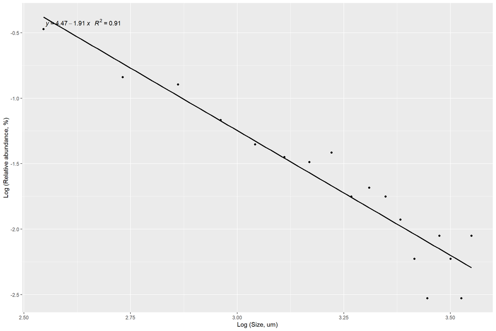

```r
ggplot(data = trimmedsediment, aes(x = logSize, y = logAbundance)) +
   geom_smooth(method = "lm", se=FALSE, color="black", formula = my.formula) +
   stat_poly_eq(formula = my.formula,
                aes(label = paste(..eq.label.., ..rr.label.., sep = "~~~")),
                parse = TRUE) +
   geom_point() +
  xlab("Log (Size, um)") +
  ylab("Log (Relative abundance, %)")
```

### 2.2.5 Tissue

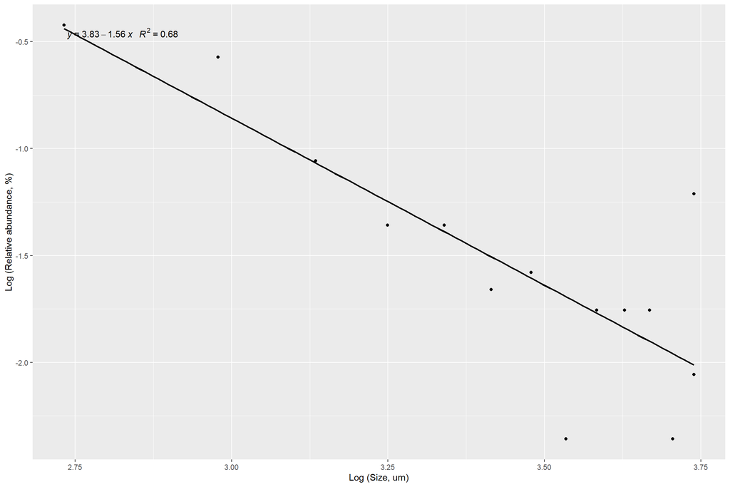

```r
#determine lower and upper end based on maximum R^2 (iteration required)
tissue_cut <- distributions %>%
  #filter(lower_size_limit_um == 125) %>%
 # filter(MorphologicalCategory == "Fragment") %>%
  filter(matrix == "tissue") %>%
  #filter(Size_um >1 & Size_um  <1000) %>%
  drop_na(Size_um)

#cut into bins
#tissuewinsors <- rbin_winsorize(tissue_cut, polymer, Size_um, 20)
tissuewinsors <- rbin_winsorize(tissue_cut, predictor = Size_um, Size_um, bins = 14, winsor_rate = 0.05)
#save as dataframe
tissuebinned <- as.data.frame(tissuewinsors$bins) %>%
  dplyr::select(c(cut_point, bin_count, bin_prop))

#strip of characters
tissuebinned$cut <- gsub("[^0-9.-]","",tissuebinned$cut_point)
 #convert to numeric
tissuebinned2 <- tissuebinned %>%
  mutate(cut.numeric = as.numeric(cut)) %>%
  mutate(logAbundance = log10(bin_prop),
         logSize = log10(cut.numeric))

## model
library(ggpmisc)
my.formula <- y ~ x
p <- tissuebinned2 %>%
  #filter(logAbundance < -1.0) %>%
  ggplot(aes(x = logSize, y = logAbundance)) +
   geom_smooth(method = "lm", se=FALSE, color="black", formula = my.formula) +
   stat_poly_eq(formula = my.formula,
                aes(label = paste(..eq.label.., ..rr.label.., sep = "~~~")),
                parse = TRUE) +
   geom_point() +
  xlab("Log (Size, um)") +
  ylab("Log (Relative abundance, %)")
p
```

##### 2.2.5.0.1 Remove outliers

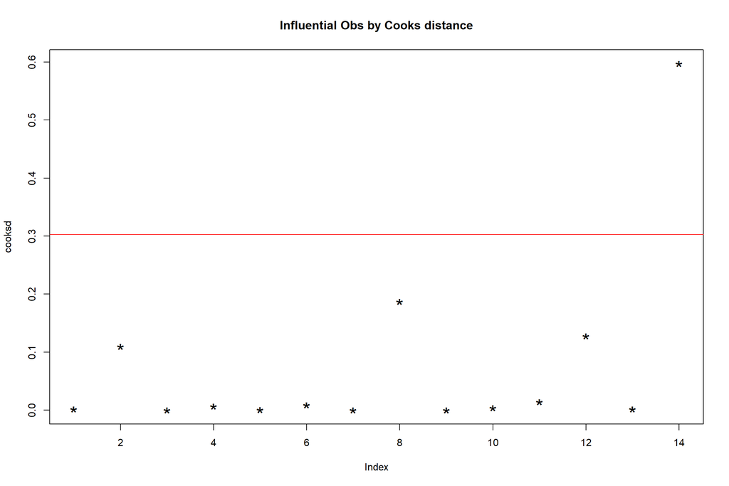

```r
tissuelin <- lm(logAbundance ~ logSize, data = tissuebinned2)
cooksd <- cooks.distance(tissuelin)
plot(cooksd, pch="*", cex=2, main="Influential Obs by Cooks distance")  # plot cook's distance
abline(h = 4*mean(cooksd, na.rm=T), col="red")  # add cutoff line
text(x=1:length(cooksd)+1, y=cooksd, labels=ifelse(cooksd>4*mean(cooksd, na.rm=T),names(cooksd),""), col="red")  # add labels
```

Extract outliers

```r
influential <- as.numeric(names(cooksd)[(cooksd > 4*mean(cooksd, na.rm=T))])  # influential row numbers
head(tissuebinned2[influential, ])  # influential observations.
```

```
##              cut_point bin_count   bin_prop              cut cut.numeric
## 14 >= 5480.51785714286        14 0.06140351 5480.51785714286    5480.518
##    logAbundance  logSize
## 14    -1.211807 3.738822
```

```r
trimmedtissue <- tissuebinned2[-influential,] %>%
  mutate(polymer = "tissue")

tissuelin <- lm(logAbundance ~ logSize, data = trimmedtissue)
tissuelin.summ <- summary(tissuelin)
tissuelin.summ
```

```
##
## Call:
## lm(formula = logAbundance ~ logSize, data = trimmedtissue)
##
## Residuals:
##      Min       1Q   Median       3Q      Max
## -0.57110 -0.08621  0.07749  0.12012  0.27281
##
## Coefficients:
##             Estimate Std. Error t value Pr(>|t|)
## (Intercept)   4.5992     0.7674   5.993 9.01e-05 ***
## logSize      -1.8069     0.2250  -8.032 6.29e-06 ***
## ---
## Signif. codes:  0 '***' 0.001 '**' 0.01 '*' 0.05 '.' 0.1 ' ' 1
##
## Residual standard error: 0.237 on 11 degrees of freedom
## Multiple R-squared:  0.8543, Adjusted R-squared:  0.8411
## F-statistic: 64.52 on 1 and 11 DF,  p-value: 6.287e-06
```

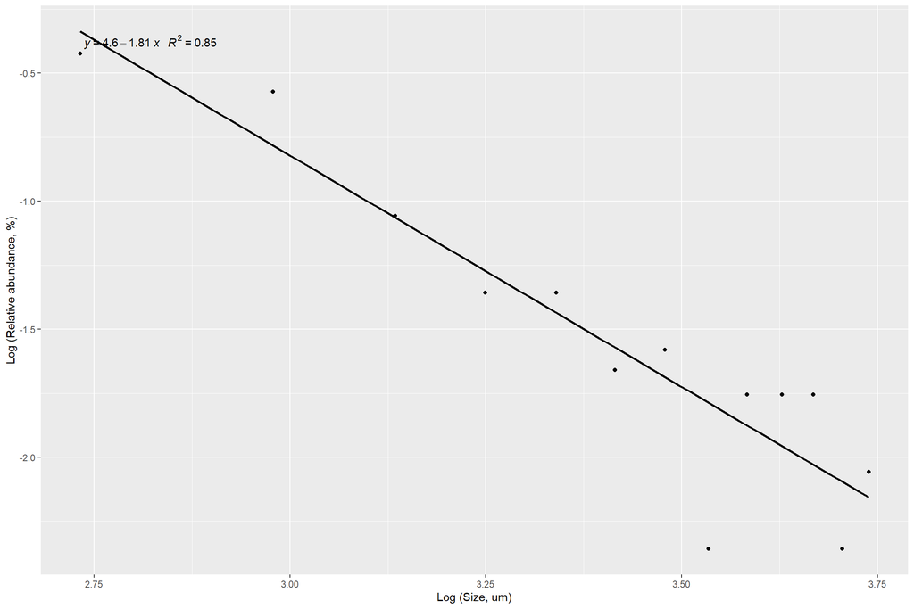

```r
ggplot(data = trimmedtissue, aes(x = logSize, y = logAbundance)) +
   geom_smooth(method = "lm", se=FALSE, color="black", formula = my.formula) +
   stat_poly_eq(formula = my.formula,
                aes(label = paste(..eq.label.., ..rr.label.., sep = "~~~")),
                parse = TRUE) +
   geom_point() +
  xlab("Log (Size, um)") +
  ylab("Log (Relative abundance, %)")
```

## 2.3 Compare individual and all combined

### 2.3.1 Scatterplot

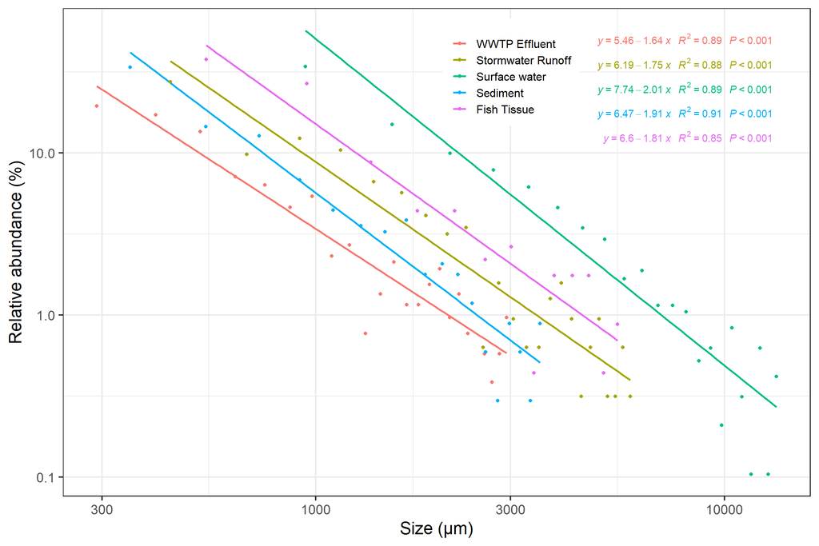

```r
#recombine datasets
trimmed_combined <- rbind(trimmedeffluent %>% mutate(matrix = "effluent"),
      trimmedrunoff %>% mutate(matrix = "runoff"),
      trimmedsample_water %>% mutate(matrix = "sample_water"),
      trimmedsediment %>% mutate(matrix = "sediment"),
      trimmedtissue %>% mutate(matrix = "tissue"))


scatterplot <- trimmed_combined %>%
  ggplot(aes(x = 10^logSize, y = 10^logAbundance * 100, color = matrix, fill = matrix)) +
   geom_smooth(method = "lm", se=FALSE, formula = my.formula) +
   stat_poly_eq(formula = my.formula,
                aes(label = paste(..eq.label.., ..rr.label.., ..p.value.label.., sep = "~~~")),
                label.x  = "right",
                label.y = "top",
                parse = TRUE) +
  scale_color_discrete(labels = c("WWTP Effluent", "Stormwater Runoff", "Surface water", "Sediment", "Fish Tissue")) +
  scale_fill_discrete(labels = c("WWTP Effluent", "Stormwater Runoff", "Surface water", "Sediment", "Fish Tissue")) +
   geom_point() +
  scale_x_log10() +
  scale_y_log10() +
  xlab("Size (μm)") +
  ylab("Relative abundance (%)") +
  theme_bw(base_size = 18) +
  theme(legend.position = c(0.6,0.87),
        legend.title = element_blank(),
        #legend.background = element_rect(color = "black", fill = "white", linetype = "solid"),
        legend.text = element_text(size = 12))

scatterplot
```

```r
ggsave(plot = scatterplot,
       filename = "PDF_scatterplot.jpg",
       path = "./output/figures/",
       width = 12, height = 8, units = "in",
       dpi = 300)
```

### 2.3.2 Table

```r
matrix <- c("samplewater", "effluent", "runoff", "sediment", "tissue")

count <- distributions %>%
  filter(matrix != "blankwater") %>%
  group_by(matrix) %>%
  summarise(count = n())


Lmin <- c(min(trimmedsample_water$logSize), min(trimmedeffluent$logSize), min(trimmedrunoff$logSize), min(trimmedsediment$logSize), min(trimmedtissue$logSize))

preds <- c(sample_waterlin$coefficients[2], effluentlin$coefficients[2], runofflin$coefficients[2], sedimentlin$coefficients[2], tissuelin$coefficients[2])

stderrors <- c(sample_waterlin.summ$coefficients[2,2], effluentlin.summ$coefficients[2,2], runofflin.summ$coefficients[2,2], sedimentlin.summ$coefficients[2,2], tissuelin.summ$coefficients[2,2])

R2 <- c(sample_waterlin.summ$r.squared, effluentlin.summ$r.squared, runofflin.summ$r.squared, sedimentlin.summ$r.squared, tissuelin.summ$r.squared)

p.values <- c(sample_waterlin.summ$coefficients[2,4], effluentlin.summ$coefficients[2,4], runofflin.summ$coefficients[2,4], sedimentlin.summ$coefficients[2,4], tissuelin.summ$coefficients[2,4])

summary <- tibble(matrix,preds, stderrors, R2, p.values, Lmin) %>%
  mutate(Lmin_um = 10^Lmin) %>%
  dplyr::select(-Lmin) %>%
  left_join(count)

summary
```

```
## # A tibble: 5 x 7
##   matrix      preds stderrors    R2 p.values Lmin_um count
##   <chr>       <dbl>     <dbl> <dbl>    <dbl>   <dbl> <int>
## 1 samplewater -2.01     0.162 0.886 6.98e-11    943.  2059
## 2 effluent    -1.64     0.123 0.894 1.01e-11    291.   537
## 3 runoff      -1.75     0.140 0.876 1.93e-11    441.   324
## 4 sediment    -1.91     0.151 0.909 9.98e-10    351.   338
## 5 tissue      -1.81     0.225 0.854 6.29e- 6    540.   230
```

```r
write.csv(summary,"output/data/PDFs.csv")
```

### 2.3.4 Fit distributions

The following section is incomplete.

Which distributions fits the data best?